# Midterm #2

Duncan Gates

25 November, 2020

## Question 1

The length of life of oil-drilling bits depends upon the type of rock and soil that the drill encounters, but it is estimated that the mean length of life is 75 hours. An oil exploration company purchases drill bits whose lengths of life is approximately normally distributed with mean 75 hours and standard deviation 12 hours. The company operates the drill bits 24 hours a day.

### 1. What proportion of the company’s drill bits will fail before 60 hours of use?

Given that the length of life of the drill bits is normally distributed with $\mu= 75$ hours and $\sigma = 12$ hours, we have

$$\begin{aligned}
P(Y<60)&=P(\frac{Y-\mu}{\sigma}<\frac{60-75}{\sigma}) \\
&=P(\frac{Y-75}{12}<\frac{60-75}{12}) \\
&= P(Z)<-1.25 \\
&= \boxed{0.1056} \;\;\text{according to R}
\end{aligned}$$

### 2. What proportion of the company’s drill bits will last at least 60 hours

$$\begin{aligned}
P(Y>60)&=P(\frac{Y-\mu}{\sigma}>\frac{60-75}{\sigma}) \\
&=P(\frac{Y-75}{12}>\frac{60-75}{12}) \\
&= P(Z)>-1.25 \\
&= \boxed{.8944} \;\;\text{according to R}\\
&\text{This result can also be reached with } 1-0.1056
\end{aligned}$$

### 3. What proportion of the company’s drill bits will have to be replaced after more than 90 hours of use?

$$\begin{aligned}
P(Y>90)&=P(\frac{Y-\mu}{\sigma}>\frac{90-75}{\sigma}) \\
&=P(\frac{Y-75}{12}>\frac{90-75}{12}) \\
&= P(Z)>1.25 \\
&= \boxed{0.1056} \;\;\text{according to R}\\
\end{aligned}$$

### 4. If the company starts the week operating 10 wells with brand new bits, what is the probability that operation of at least 2 wells will have to stop after 2 days because the drill bits have failed?

The probability that 2 drill bits fail after 2 days (48 hours) is,

$$\begin{aligned}
P(Y>48)&=P(Z>\frac{x-\mu}{\sigma}) \\
&=P(Z>\frac{48-75}{12}) \\
&= P(Z)>-2.25 \\
&= 0.9878 \;\;\text{according to R}\\
\end{aligned}$$

I do not know how to do the rest of this.

## Question 2

Let (X, Y) denote the coordinates of a point selected at random inside the unit circlewhose center is at the origin. That is, X and Y have a joint density function given by
$$f(x,y)=\frac{1}{\pi} \text{when } x^2+y^2\le 1 \text{ and 0 otherwise}$$

### 1. Find P(Y>X).

The total probability of the unit circle is 1, and each point on the circle has an equal probability of $\frac{1}{\pi}$. The probability that $P(Y>X)$ is therefore the integral of half of the circle

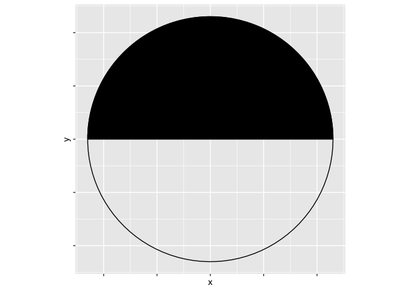

, thus

$$\begin{aligned}
P(Y>X)&=\frac{1}{2}
\end{aligned}$$

### 2. Compute the marginal densities of X and Y.

The marginal densities of X and Y are,

$$\begin{aligned}
f_Y(y)&=\int_0^1 \frac{1}{\pi}dy \\
&=\Bigg[\frac{y}{\pi}\Bigg]_0^1 \\
&=\boxed{\frac{1}{\pi}} \\
f_X(x)&=\int_0^1 \frac{1}{\pi}dx \\
&=\Bigg[\frac{x}{\pi}\Bigg]_0^1 \\
&=\boxed{\frac{1}{\pi}} \\
\end{aligned}$$

### 3. Argue that X and Y are not independent.

If X and Y are independent random variables then $Cov(X, Y)= 0$. We know that $Cov(X, Y)= E(XY)-\mu_1\mu_2$

$$\begin{aligned}
E(XY)&=\int_{0}^{1}\int_{0}^{1}xy\frac{1}{\pi}dxdy \\
&=\frac{1}{\pi}\int_{0}^{1}\int_{0}^{1}xy\:dxdy \\
&=\frac{1}{\pi}\int_{0}^{1}\Bigg[\frac{1}{2}x^2y\Bigg]_0^1dy \\
&=\frac{1}{\pi}\Bigg[\frac{1}{4}x^2y^2\Bigg]_0^1 \\
&= \frac{1}{4\pi}
\end{aligned}$$

$$\begin{aligned}
E(X)&=\int_{0}^{1}\int_{0}^{1}x\frac{1}{\pi}dxdy \\
&=\frac{1}{\pi}\int_{0}^{1}\Bigg[\frac{x^2}{2} \Bigg]_0^1dy \\
&=\frac{1}{\pi}\int_{0}^{1}\frac{1}{2}dy \\
&=\frac{1}{\pi}\Bigg[\frac{y}{2} \Bigg]_0^1 \\
&= \frac{1}{2\pi}
\end{aligned}$$

$$\begin{aligned}
E(Y)&=\int_{0}^{1}\int_{0}^{1}y\frac{1}{\pi}dxdy \\
&=\frac{1}{\pi}\int_{0}^{1}\Bigg[xy \Bigg]_0^1dy \\
&=\frac{1}{\pi}\int_{0}^{1}ydy \\
&=\frac{1}{\pi}\Bigg[\frac{y^2}{2} \Bigg]_0^1 \\
&= \frac{1}{2\pi}
\end{aligned}$$

$$\begin{aligned}
Cov(X, Y)&= E(XY)-\mu_1\mu_2 \\
E(XY)&=\frac{1}{4\pi} \text{ and }\mu_1,\mu_2=\frac{1}{2\pi} \\
\frac{1}{4\pi}&\ne\frac{1}{2\pi}*\frac{1}{2\pi}
\end{aligned}$$

Therefore X and Y are not independent.

### 4. Compute E(XY) and Cov(X,Y)

**THIS IS DONE ABOVE**

### 5. Compute the conditional density of Y|X = x and E(Y|X=0)

Using the calculations above

$$\begin{aligned}
P(Y|X=x)&=\frac{P(X=x, Y=y)}{P(X=x)} \\
&= \frac{\frac{1}{2\pi}^2}{\frac{1}{2\pi}} \\
&=\frac{\pi}{2\pi^2}
\end{aligned}$$

and,

$$\begin{aligned}
E(Y|X=0)&= 0\\
\end{aligned}$$

## Problem 3

### 1. Find c that makes f(y) a density function.

$$\begin{aligned}
1&=\int_{-\infty}^{\infty}f(y)dy \\
&=\int_0^{\infty}cye^{-2y}dy \\
\text{Let } &u = cy \text{ and } dv=e^{-2y}dy \\
&=cy\frac{e^{-2y}}{2}\Bigg|_0^{\infty} - c\int_0^{\infty}\frac{e^{-2y}}{-2}dy \\
&=0+c\int_0^{\infty}\frac{1}{2}e^{-2y}dy \\
&=c\Bigg[\frac{e^{-2y}}{-4} \Bigg]_0^{\infty} \\
c&=\boxed{4}
\end{aligned}$$

### 2. Compute P(Y>t) and P(Y>t+s|Y>t). Does the distribution of Y have the memoryless property? Integration by parts may help here.

We see that Y is a gamma density function that therefore takes the shape $\frac{y^{\alpha-1}e^{-y/\beta}}{\beta^{\alpha}\tau(\alpha)}$ with $\alpha = 2$, $\beta = 0.5$. Therefore,

$$\begin{aligned}
P(Y>t)&=\int_t^{\infty}4ye^{-2y}dy \\
&=4\int_t^{\infty}ye^{-2y}dy \\
\text{Let } &u = y \text{ and } dv = e^{-2y}dy \\
&= 2e^{-2y}y\Bigg|_t^{\infty} + 2\int_t^{\infty}e^{-2y}dy \\
&=2e^{-2t}t+2\int_t^{\infty}e^{-2y}dy \\
\text{Let } u& = -2y \\
&=2e^{-2t}t+\int_{-2t}^{\infty}-e^udu \\
&=2e^{-2t}+e^{2t} \\
&= e^{-2t}(2t+1)
\end{aligned}$$

$$\begin{aligned}
P(Y>t+s)&=\int_{t+s}^{\infty}4ye^{-2y}dy \\
&=4\int_{t+s}^{\infty}ye^{-2y}dy \\
\text{Let } &u = y \text{ and } dv = e^{-2y}dy \\
&= 2e^{-2y}y\Bigg|_{t+s}^{\infty} + 2\int_{t+s}^{\infty}e^{-2y}dy \\
&=2e^{-2(t+s)}(t+s)+2\int_{t+s}^{\infty}e^{-2y}dy \\
\text{Let } u& = -2y \\
&=2e^{-2(t+s)}(t+s)+2\int_{-2t-2s}^{\infty}-e^udu \\
&=2e^{-2(t+s)}(t+s)+ 2*\frac{1}{2}e^{-2(s+t)}\\
&= 2e^{-2(t+s)}(t+s)+e^{-2(s+t)} \\
&=e^{-2(s+t)}(2s+2t+1)
\end{aligned}$$

So we have,

$$\begin{aligned}
P(Y>t+s|Y>t)&=\frac{e^{-2(s+t)}(2s+2t+1)}{e^{-2t}(2t+1)} \\
&=\frac{e^{-2s}(2s+2t+1)}{2t+1}
\end{aligned}$$

Which does not appear to have the memoryless property.

### 3. Compute the moment generating function for Y.

The moment generating function of a gamma random variable is $M(t)=(\frac{1}{1-\beta t})^{\alpha}$ if $t > \frac{1}{\beta}$ so we have,

$$\begin{aligned}
M_Y(t)&=(\frac{1}{1-\frac{1}{2}t})^{2} \\
&= \frac{4}{(2-t)^2}
\end{aligned}$$

### 4. Suppose that X & Y are independent random variables with density f(y). Compute the moment generating function of X + Y. Can you recognize the distribution of X + Y?

The moment generating function of Y is calculated above and we know that $M(t) = E(e^{tY} )$, therefore

$$\begin{aligned}
M_{X+Y}(t)&=E(e^{t(X+Y)}) \\
&=E(e^{tx})*E(e^{ty}) \\
&=M_Y(t)^2 \\
M_Y(t)^2&=\Bigg(\frac{4}{(2-t)^2}\Bigg)^2 \\
&=\frac{16}{(2-t)^4}
\end{aligned}$$

Using $M(t)=(\frac{1}{1-\beta t})^{\alpha}$ we therefore find that $\alpha = 4$, and $\beta = \frac{1}{2}$, another gamma distribution function.